# Analyse de survie : Comparaison des méthodes classiques et SVM

Timothée TEMPLIER - Samuel BALLU

2025-03-14

# Introduction

L’analyse de survie est une branche essentielle de la statistique permettant d’étudier le temps avant la survenue d’un événement d’intérêt, comme le décès d’un patient ou la progression d’une maladie. Dans le cadre de cette étude, nous utilisons les données veteran issues du package survival, qui regroupent des informations sur des patients atteints d’un cancer du poumon.

L’objectif de cette analyse est double :

1. Explorer et comparer différentes méthodes d’analyse de survie afin d’évaluer leur pertinence et leur performance sur les données disponibles.
2. Optimiser et comparer la performance des modèles en se basant sur des métriques adaptées, comme le C-index de Harrell, pour identifier la méthode la plus robuste.

Plus précisément, nous mettrons en œuvre les approches suivantes :

- **Méthodes non paramétriques**, notamment l’estimateur de Kaplan-Meier pour estimer la courbe de survie et observer les tendances globales.
- **Tests statistiques**, en appliquant le log-rank test pour comparer les courbes de survie entre les groupes de traitement.
- **Modèle semi-paramétrique de Cox**, afin d’identifier les variables influençant la survie et tester l’hypothèse des risques proportionnels.
- **Machines à vecteurs de support pour la survie (SVM)**, une approche d’apprentissage automatique permettant de modéliser la durée de survie en prenant en compte la censure des données, avec optimisation des hyperparamètres via validation croisée.

# Chargement des packages et des données

Les données data(veteran) représentent un échantillon de 137 patients atteints d’un cancer du poumon, répartis en deux groupes de traitement (standard et test). Les variables disponibles sont les suivantes :

- **time** : Temps de survie ou temps jusqu’à l’événement (en jours).
- **status** : Statut de l’événement (1 = décès, 0 = censure).
- **trt** : Traitement reçu (1 = standard, 2 = test).
- **age** : Âge du patient.
- **karno** : Score de performance de Karnofsky.
- **diagtime** : Temps écoulé depuis le diagnostic (en jours).
- **celltype** : Type de cellule cancéreuse.

```r
# Chargement des packages nécessaires
library(survival)
library(survminer)
library(dplyr)
library(ggplot2)
library(survivalsvm)
library(caret)
library(tidymodels)
# Chargement des données
data(veteran)
```

```r
table(veteran$celltype)
```

```
##
##  squamous smallcell     adeno     large
##        35        48        27        27
```

# Analyse exploratoire des données

```r
# Statistiques descriptives par traitement
veteran %>%
  group_by(trt) %>%
  summarise(
    n = n(),
    temps_moyen = mean(time),
    temps_median = median(time),
    deces = sum(status == 1),
    taux_deces = mean(status == 1)
  )
```

```
## # A tibble: 2 × 6
##     trt     n temps_moyen temps_median deces taux_deces
##   <dbl> <int>       <dbl>        <dbl> <int>      <dbl>
## 1     1    69        115.         97      64      0.928
## 2     2    68        128.         52.5    64      0.941
```

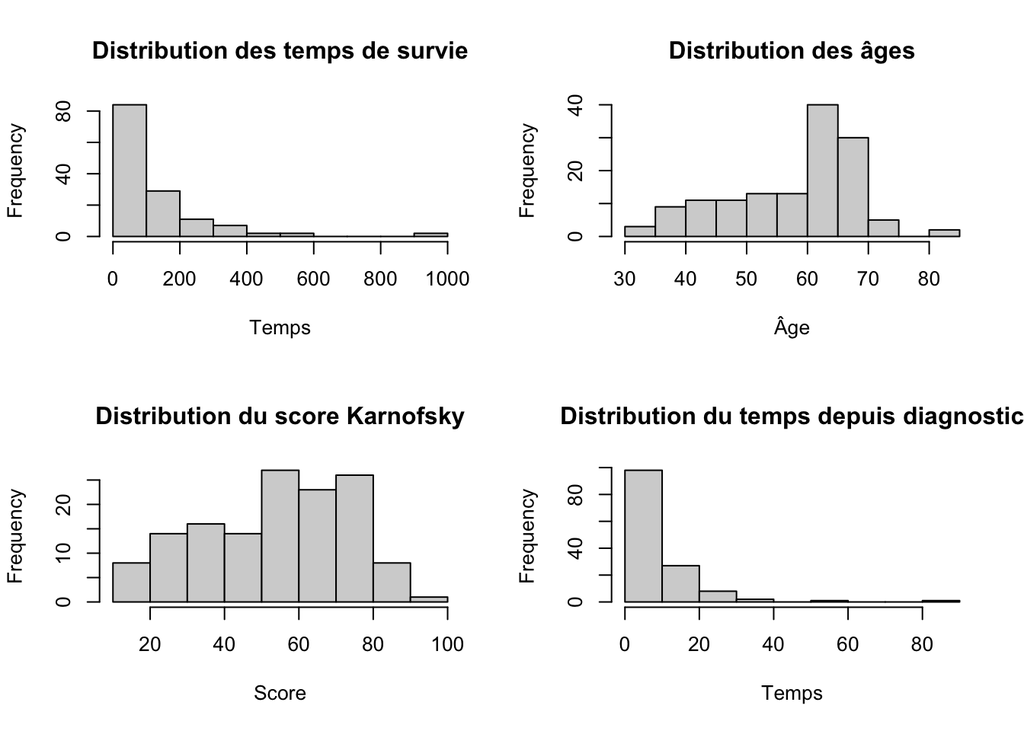

```r
# Distribution des variables continues
par(mfrow = c(2, 2))
hist(veteran$time, main = "Distribution des temps de survie", xlab = "Temps")
hist(veteran$age, main = "Distribution des âges", xlab = "Âge")
hist(veteran$karno, main = "Distribution du score Karnofsky", xlab = "Score")
hist(veteran$diagtime, main = "Distribution du temps depuis diagnostic", xlab = "Temps")
```

```r
#View(veteran)
```

On peut aussi remarquer que nous avons affaire à des données qui concernent des individus assez âgées (la plus part ont plus de 60 ans).

# Analyse de survie non paramétrique (Kaplan-Meier)

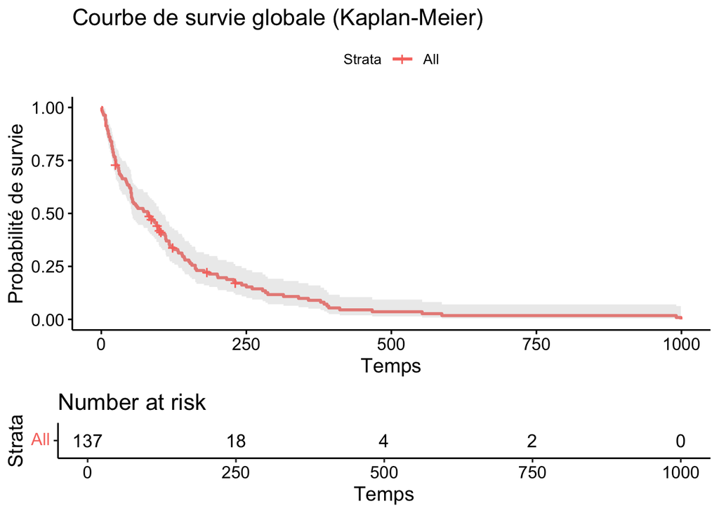

```r
# Création de l'objet de survie
surv_obj <- Surv(veteran$time, veteran$status)

# Estimation Kaplan-Meier globale
km_fit <- survfit(surv_obj ~ 1)

# Visualisation
ggsurvplot(km_fit,
           data = veteran,
           risk.table = TRUE,
           conf.int = TRUE,
           xlab = "Temps",
           ylab = "Probabilité de survie",
           title = "Courbe de survie globale (Kaplan-Meier)")
```

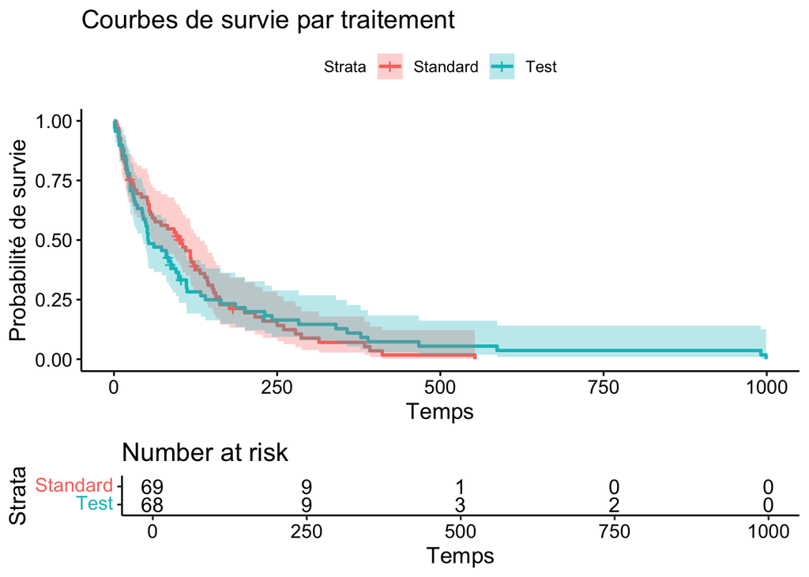

```r
# Estimation Kaplan-Meier par traitement
km_trt <- survfit(surv_obj ~ trt, data = veteran)

# Visualisation par traitement
ggsurvplot(km_trt,
           data = veteran,
           risk.table = TRUE,
           conf.int = TRUE,
           xlab = "Temps",
           ylab = "Probabilité de survie",
           title = "Courbes de survie par traitement",
           legend.labs = c("Standard", "Test"))
```

Les graphiques de survie comparent deux traitements, “Standard” et “Test”. La courbe de survie du traitement “Test” suggère une meilleure survie globale, à partir de 200 jours. Cependant, les différences ne sont pas très importantes et les intervalles de confiance se chevauchent, ce qui pourrait indiquer une absence de significativité statistique. Pour confirmer ces observations, une analyse statistique plus approfondie est nécessaire, en tenant compte d’autres facteurs pouvant influencer la survie des patients.

Maintenant observons si il y a une différence de temps de survie entre les deux traitement selon le type de cellule.

Rapel : notre jeu de donnée contient 4 type de cellule :

```r
table(veteran$celltype)
```

```
##
##  squamous smallcell     adeno     large
##        35        48        27        27
```

Pour les **squamous :**

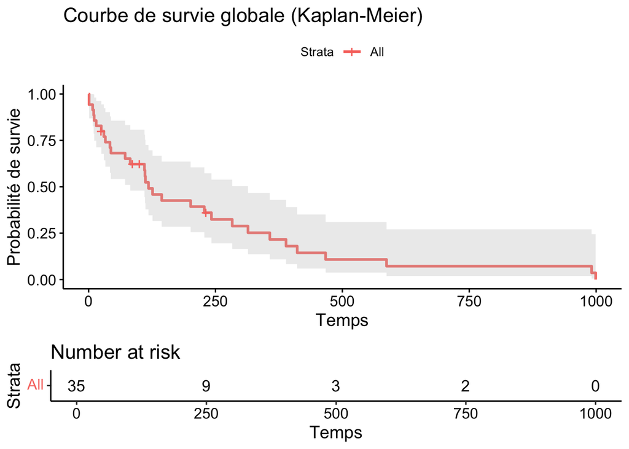

```r
df_bis = veteran[veteran$celltype == 'squamous',]

# Création de l'objet de survie
surv_obj <- Surv(df_bis$time, df_bis$status)

# Estimation Kaplan-Meier globale
km_fit <- survfit(surv_obj ~ 1)

# Visualisation
ggsurvplot(km_fit,
           data = df_bis,
           risk.table = TRUE,
           conf.int = TRUE,
           xlab = "Temps",
           ylab = "Probabilité de survie",
           title = "Courbe de survie globale (Kaplan-Meier)")
```

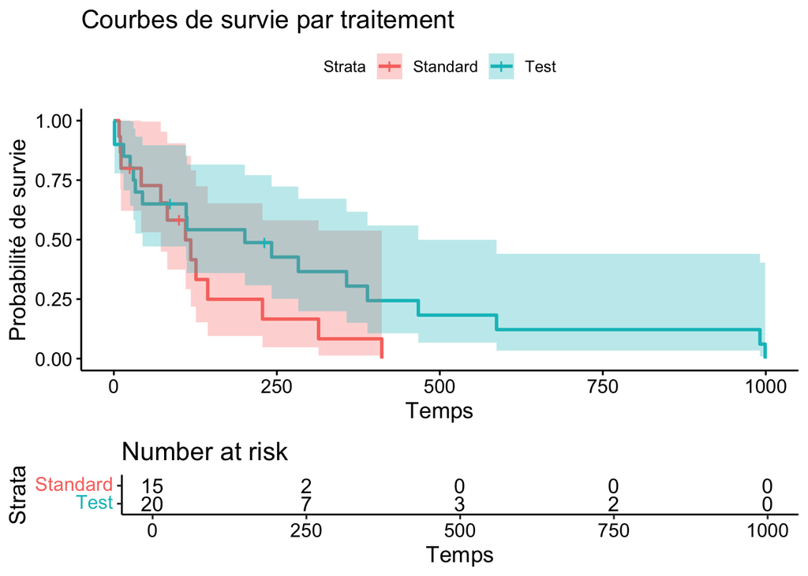

```r
# Estimation Kaplan-Meier par traitement
km_trt <- survfit(surv_obj ~ trt, data = df_bis)

# Visualisation par traitement
ggsurvplot(km_trt,
           data = df_bis,
           risk.table = TRUE,
           conf.int = TRUE,
           xlab = "Temps",
           ylab = "Probabilité de survie",
           title = "Courbes de survie par traitement",
           legend.labs = c("Standard", "Test"))
```

On observe une plus grande probabilité de survie pour le traitement “Test” à partir de 100 jours. Avant cela, les résultats sont similaires pour ce traitement pour les individus avec les cellules squameuses.

Pour les **smallcell :**

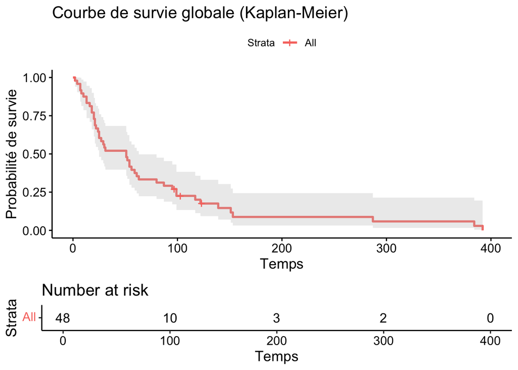

```r
df_bis = veteran[veteran$celltype == 'smallcell',]

# Création de l'objet de survie
surv_obj <- Surv(df_bis$time, df_bis$status)

# Estimation Kaplan-Meier globale
km_fit <- survfit(surv_obj ~ 1)

# Visualisation
ggsurvplot(km_fit,
           data = df_bis,
           risk.table = TRUE,
           conf.int = TRUE,
           xlab = "Temps",
           ylab = "Probabilité de survie",
           title = "Courbe de survie globale (Kaplan-Meier)")
```

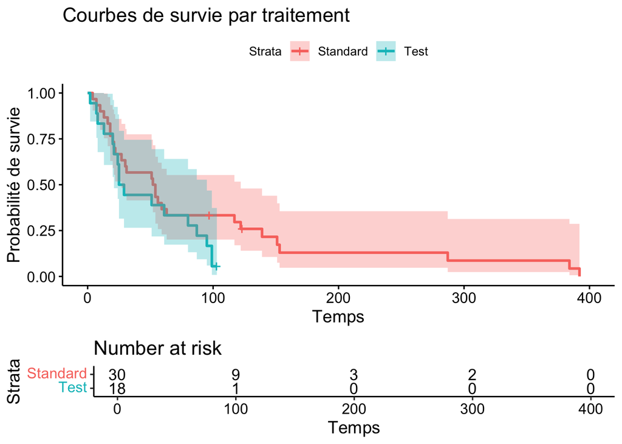

```r
# Estimation Kaplan-Meier par traitement
km_trt <- survfit(surv_obj ~ trt, data = df_bis)

# Visualisation par traitement
ggsurvplot(km_trt,
           data = df_bis,
           risk.table = TRUE,
           conf.int = TRUE,
           xlab = "Temps",
           ylab = "Probabilité de survie",
           title = "Courbes de survie par traitement",
           legend.labs = c("Standard", "Test"))
```

On observe une plus grande probabilité de survie pour le traitement “Standard” à partir de 75 jours. Avant cela, les résultats sont similaires pour ce traitement pour les individus avec les cellules smallcell.

Pour les **adeno :**

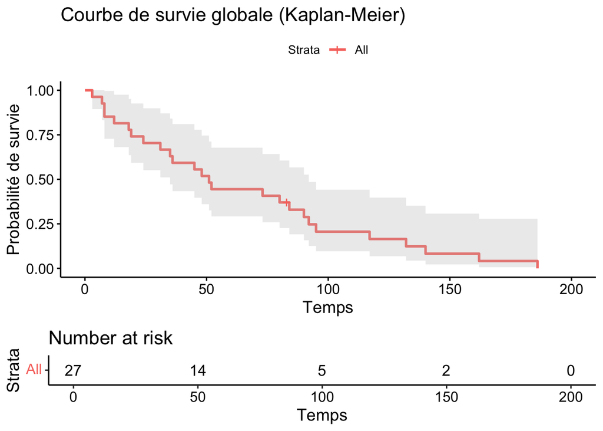

```r
df_bis = veteran[veteran$celltype == 'adeno',]

# Création de l'objet de survie
surv_obj <- Surv(df_bis$time, df_bis$status)

# Estimation Kaplan-Meier globale
km_fit <- survfit(surv_obj ~ 1)

# Visualisation
ggsurvplot(km_fit,
           data = df_bis,
           risk.table = TRUE,
           conf.int = TRUE,
           xlab = "Temps",
           ylab = "Probabilité de survie",
           title = "Courbe de survie globale (Kaplan-Meier)")
```

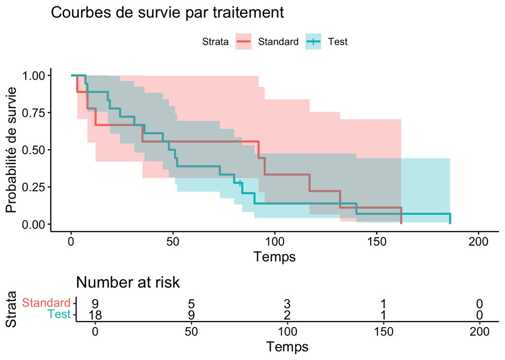

```r
# Estimation Kaplan-Meier par traitement
km_trt <- survfit(surv_obj ~ trt, data = df_bis)

# Visualisation par traitement
ggsurvplot(km_trt,
           data = df_bis,
           risk.table = TRUE,
           conf.int = TRUE,
           xlab = "Temps",
           ylab = "Probabilité de survie",
           title = "Courbes de survie par traitement",
           legend.labs = c("Standard", "Test"))
```

On a des résultats assez similaire pour les deux traitements pour les individus avec les cellules adeno.

Pour les **large :**

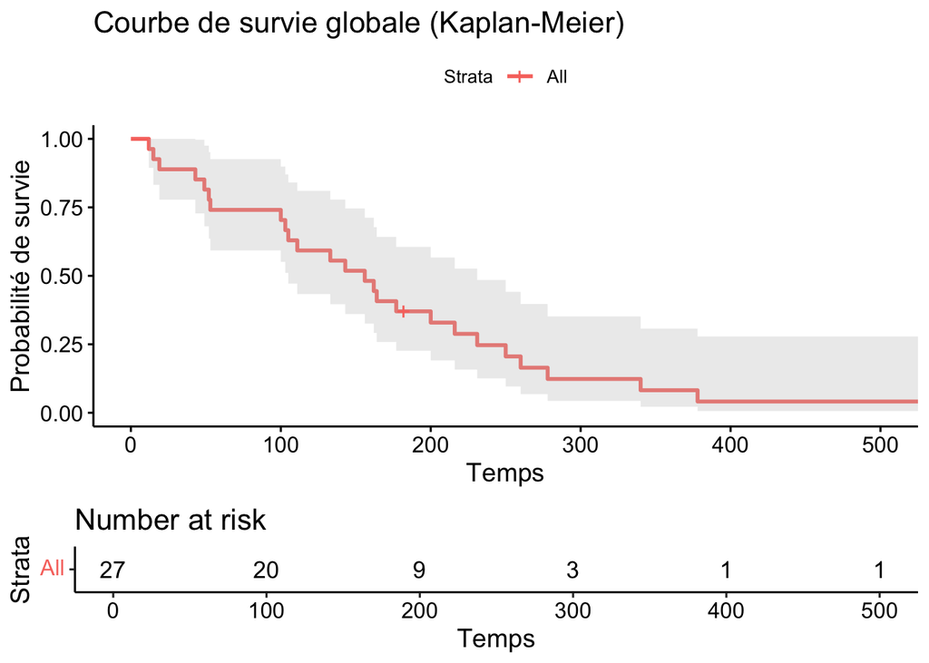

```r
df_bis = veteran[veteran$celltype == 'large',]

# Création de l'objet de survie
surv_obj <- Surv(df_bis$time, df_bis$status)

# Estimation Kaplan-Meier globale
km_fit <- survfit(surv_obj ~ 1)

# Visualisation
ggsurvplot(km_fit,
           data = df_bis,
           risk.table = TRUE,
           conf.int = TRUE,
           xlab = "Temps",
           ylab = "Probabilité de survie",
           title = "Courbe de survie globale (Kaplan-Meier)")
```

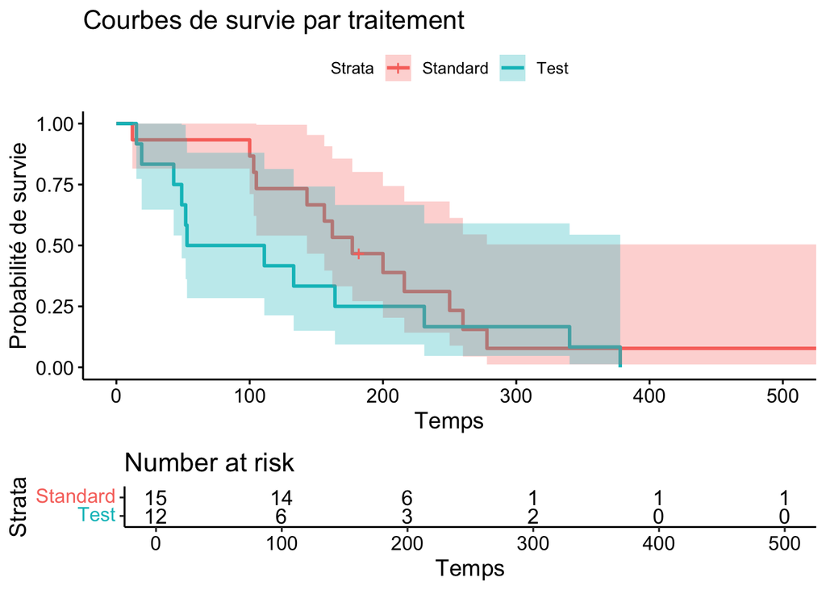

```r
# Estimation Kaplan-Meier par traitement
km_trt <- survfit(surv_obj ~ trt, data = df_bis)

# Visualisation par traitement
ggsurvplot(km_trt,
           data = df_bis,
           risk.table = TRUE,
           conf.int = TRUE,
           xlab = "Temps",
           ylab = "Probabilité de survie",
           title = "Courbes de survie par traitement",
           legend.labs = c("Standard", "Test"))
```

On obtient une meilleure probabilité de survie pour le traitement standard lors des premiers jours de traitement. Cependant, cette différence est atténuée par l’intervalle de confiance qui se chevauche entre les deux traitements, pour les individus ayant des cellules larges.

# Test du log-rank

```r
# Test du log-rank pour comparer les traitements
log_rank <- survdiff(Surv(time, status) ~ trt, data = veteran)
print(log_rank)
```

```
## Call:
## survdiff(formula = Surv(time, status) ~ trt, data = veteran)
##
##        N Observed Expected (O-E)^2/E (O-E)^2/V
## trt=1 69       64     64.5   0.00388   0.00823
## trt=2 68       64     63.5   0.00394   0.00823
##
##  Chisq= 0  on 1 degrees of freedom, p= 0.9
```

Les résultats du log-rank montrent que le test n’est pas significatif (p-value = 0.9), ce qui signifie qu’il n’y a pas de différence statistiquement significative entre les courbes de survie des deux traitements. Cela confirme les observations précédentes basées sur les courbes de survie Kaplan-Meier.

On n’appliquera pas ce test selon le type de cellule de l’individu, car nous ne disposons pas d’assez d’individus par cellule pour le valider.

# Modèle de Cox

```r
# Redéfinir l'objet de survie pour l'ensemble complet des données
surv_obj <- Surv(veteran$time, veteran$status)

# Ajustement du modèle de Cox
cox_model <- coxph(Surv(time, status) ~ trt + age + karno + diagtime + celltype,
                   data = veteran)

# Résumé du modèle
summary(cox_model)
```

```
## Call:
## coxph(formula = Surv(time, status) ~ trt + age + karno + diagtime +
##     celltype, data = veteran)
##
##   n= 137, number of events= 128
##
##                        coef exp(coef)  se(coef)      z Pr(>|z|)
## trt                0.298380  1.347674  0.207503  1.438  0.15045
## age               -0.008706  0.991332  0.009309 -0.935  0.34971
## karno             -0.032586  0.967940  0.005447 -5.982 2.21e-09 ***
## diagtime           0.001339  1.001340  0.008066  0.166  0.86814
## celltypesmallcell  0.851206  2.342471  0.273011  3.118  0.00182 **
## celltypeadeno      1.183667  3.266330  0.297896  3.973 7.08e-05 ***
## celltypelarge      0.401001  1.493318  0.282665  1.419  0.15600
## ---
## Signif. codes:  0 '***' 0.001 '**' 0.01 '*' 0.05 '.' 0.1 ' ' 1
##
##                   exp(coef) exp(-coef) lower .95 upper .95
## trt                  1.3477     0.7420    0.8973    2.0240
## age                  0.9913     1.0087    0.9734    1.0096
## karno                0.9679     1.0331    0.9577    0.9783
## diagtime             1.0013     0.9987    0.9856    1.0173
## celltypesmallcell    2.3425     0.4269    1.3718    4.0000
## celltypeadeno        3.2663     0.3062    1.8218    5.8564
## celltypelarge        1.4933     0.6696    0.8581    2.5987
##
## Concordance= 0.738  (se = 0.021 )
## Likelihood ratio test= 62.01  on 7 df,   p=6e-11
## Wald test            = 62.41  on 7 df,   p=5e-11
## Score (logrank) test = 66.74  on 7 df,   p=7e-12
```

```r
# Test de l'hypothèse des risques proportionnels
cox.zph(cox_model)
```

```
##             chisq df       p
## trt       0.29350  1 0.58799
## age       1.87662  1 0.17072
## karno    12.97630  1 0.00032
## diagtime  0.00114  1 0.97306
## celltype 14.85061  3 0.00195
## GLOBAL   29.80760  7 0.00010
```

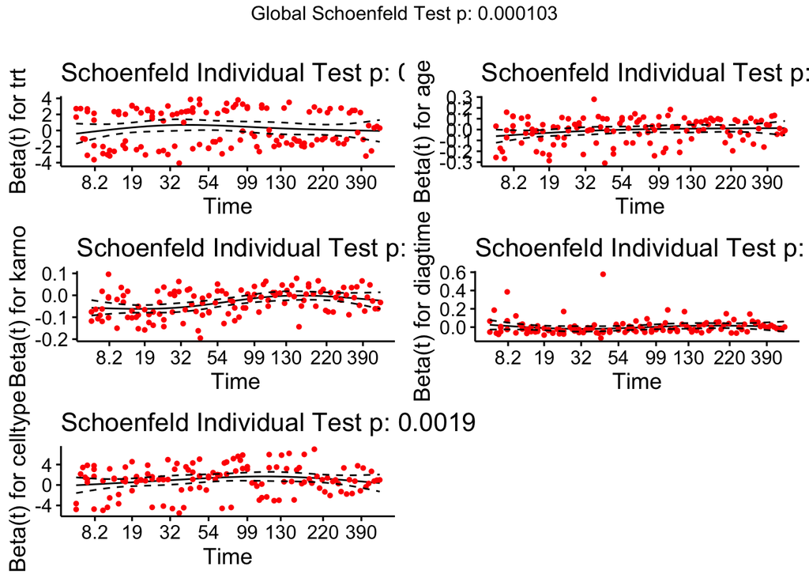

```r
# Visualisation des résidus de Schoenfeld
ggcoxzph(cox.zph(cox_model))
```

Les graphiques de Schoenfeld évaluent l’hypothèse des risques proportionnels dans un modèle de Cox. Le test global de Schoenfeld (p < 0.001) suggère une violation de cette hypothèse pour l’ensemble du modèle. Les tests individuels révèlent que le type de cellule (“celltype”) et l’indice de Karnofsky (“karno”) pourraient être à l’origine de ce problème, avec des p-values de 0.0019 et 3e-04 respectivement. Visuellement, les graphiques pour ces variables montrent des tendances qui s’écartent d’une distribution aléatoire autour de zéro, ce qui confirme un effet variable dans le temps. Les autres variables semblent respecter l’hypothèse des risques proportionnels.

# SVM pour l’analyse de survie

```r
veteran$diagtime
```

```
##   [1]  7  5  3  9 11  5 10 29 18  6  4 58  4  9 11  3  9  2  4  4  3  5 14  2  3
##  [26]  4 12  4 12  2 15  2  5  3  2 25  4  1 28  8  1  7 11  4 23 19 10  6  2  5
##  [51]  4  5  3  4 16  5 15  2 12 12  5 12  2  2  8 11  5  8 13 12  6  3  8  1  7
##  [76]  3 21  3  2  6 36 13  2 28  7 11 13  2 13  2 22  4  2  2 36  9 11  8  3  2
## [101]  4  2  2  1 17 87  8  2  5  3  3  5 22  3  3  5  8  4  4  3  3  4 10  3  4
## [126]  4 15  4 12  5 11 10  1  5 18  4  3
```

```r
set.seed(123)
n<-nrow(veteran)
train.index<-sample(1:n,0.7*n, replace = F)
test.index<-setdiff(1:n,train.index)

survsvm.reg <- survivalsvm(Surv(diagtime, status) ~ .,
 subset = train.index, data = veteran,
 type = "regression", gamma.mu = 1,
 opt.meth = "quadprog", kernel = "add_kernel")

print(survsvm.reg)
```

```
##
## survivalsvm result
##
## Call:
##
##  survivalsvm(Surv(diagtime, status) ~ ., subset = train.index, data = veteran, type = "regression", gamma.mu = 1, opt.meth = "quadprog", kernel = "add_kernel")
##
## Survival svm approach              : regression
## Type of Kernel                     : add_kernel
## Optimization solver used           : quadprog
## Number of support vectors retained : 38
## survivalsvm version                : 0.0.5
```

```r
pred.survsvm.reg <- predict(object = survsvm.reg,
 newdata = veteran, subset = test.index)

print(pred.survsvm.reg)
```

```
##
##
## survivalsvm prediction
##
## Type of survivalsvm                      : regression
## Type of kernel                           : add_kernel
## Optimization solver used in model        : quadprog
## predicted risk ranks                     : 13.29 17.32 17.27 13.28 12.96 ...
## survivalsvm version                      : 0.0.5
```

Les résultats montrent que le modèle SVM pour la survie a été ajusté avec succès, en utilisant un noyau additif et un paramètre gamma.mu de 1. Les prédictions du modèle pour les données de test sont également disponibles, fournissant des estimations des risques de survie pour chaque individu. Ces résultats peuvent être utilisés pour évaluer la performance du modèle et comparer ses prédictions avec les données réelles.

```r
mean(abs(pred.survsvm.reg$predicted - veteran$diagtime[test.index]))
```

```
## [1] 7.08936
```

On observe une MAE très élevée, ce qui suggère que notre modèle présente une faible précision prédictive. Nous allons tenter d’améliorer ses performances en optimisant les hyperparamètres à l’aide de l’indice de concordance de Harrell (C-index).

# Ajustement des paramètres par validation Kfold

Construction de la validation kfold avec le C-index de Harelle :

```r
# Charger les bibliothèques nécessaires
library(survival)   # Pour la fonction Surv et les objets de survie
library(Hmisc)      # Pour la fonction rcorr.cens qui calcule le C-index
library(caret)      # Pour la fonction createFolds qui crée les plis pour la validation croisée
```

```r
# Fonction pour calculer le C-index de Harrell
calculate_cindex <- function(pred, actual_time, actual_status) {
  # Création d'un objet de survie pour les données réelles
  surv_obj <- Surv(actual_time, actual_status)

  # Calcul du C-index (concordance)
  # Note: pour le SVM de survie en régression, des scores plus faibles indiquent un risque plus élevé
  # Donc on inverse le signe des prédictions pour le C-index
  cindex <- rcorr.cens(-pred, surv_obj)

  return(cindex["C Index"])
}

# Fonction de validation croisée pour le modèle SVM de survie
kfold_cv_survsvm <- function(data, k=5, gamma_values, kernel_types) {
  set.seed(123)

  results <- list()
  best_cindex <- -Inf
  best_params <- NULL

  for (gamma_param in gamma_values) {
    for (kernel_type in kernel_types) {
      cindex_values <- numeric(k)

      folds <- createFolds(data$status, k=k, list=TRUE, returnTrain=FALSE)

      for (i in 1:k) {
        test_indices <- folds[[i]]
        train_indices <- setdiff(1:nrow(data), test_indices)

        # Entraînement du modèle SVM de survie
        survsvm_model <- tryCatch({
          survivalsvm(Surv(diagtime, status) ~ .,
                      data = data[train_indices, ],
                      type = "regression",
                      gamma.mu = gamma_param,
                      opt.meth = "quadprog",
                      kernel = kernel_type)
        }, error = function(e) {
          cat("Erreur dans le fold", i, ":", e$message, "\n")
          return(NULL)
        })

        if (!is.null(survsvm_model)) {
          predictions_obj <- predict(survsvm_model, newdata = data[test_indices, ])
          predictions <- predictions_obj$predicted

          if (any(is.na(predictions)) || any(is.infinite(predictions))) {
            cindex_values[i] <- NA
          } else {
            cindex_values[i] <- calculate_cindex(predictions,
                                                data$diagtime[test_indices],
                                                data$status[test_indices])
          }
        } else {
          cindex_values[i] <- NA
        }
      }

      valid_indices <- !is.na(cindex_values)

      # Vérification qu'il y a des valeurs valides avant de calculer la moyenne
      if (length(cindex_values[valid_indices]) > 0) {
        mean_cindex <- mean(cindex_values[valid_indices])
        sd_cindex <- sd(cindex_values[valid_indices])
      } else {
        mean_cindex <- NA
        sd_cindex <- NA
      }

      results[[paste(gamma_param, kernel_type)]] <- list(
        cindex_by_fold = cindex_values,
        mean_cindex = mean_cindex,
        sd_cindex = sd_cindex
      )

      if (mean_cindex > best_cindex) {
        best_cindex <- mean_cindex
        best_params <- list(gamma = gamma_param, kernel = kernel_type)
      }
    }
  }

  cat("Meilleurs paramètres: gamma =", best_params$gamma, ", kernel =", best_params$kernel, "\n")
  cat("Meilleur C-index moyen:", best_cindex, "\n")

  return(list(results = results, best_params = best_params, best_cindex = best_cindex))
}
```

Définition des hyperparamètres à ajuster :

```r
gamma_values <- c(0.1, 0.5, 1, 2, 5,8,10,12,15,20,15,30)
kernel_types <- c("add_kernel")
```

```r
cv_results <- kfold_cv_survsvm(veteran, k=5, gamma_values=gamma_values, kernel_types=kernel_types)
```

```
## Meilleurs paramètres: gamma = 8 , kernel = add_kernel
## Meilleur C-index moyen: 0.4243169
```

# Conclusion

# Références

- Van Belle, V., et al. (2011). Support vector methods for survival analysis: a comparison between ranking and regression approaches.
- Harrell Jr, F. E., et al. (1982). Evaluating the yield of medical tests.
- Cox, D. R. (1972). Regression models and life-tables.